# GuideSeq report

Therapeutic Gene Editing - GENETHON, INSERM U951, Paris-Saclay University, Evry, France

[figure not shown]

The guideSeq (Genome-wide Unbiased Identification of Double-strand breaks Enabled by Sequencing) method enables comprehensive detection and quantification of off-target activity by capturing double-strand breaks across the genome through oligonucleotide tagging, followed by sequencing and bioinformatic analysis.

This report presents different tables and graphical representations to help in the interpretation of GuideSeq experiments.

Working directory : **/media/Data/common/guideseq_gnt_dev2/test**

The analysis was performed **with** bulge tolerance.

All parameters can be found in Configuration settings at the end of this document.

# Description of libraries

Table 1

| library | Cells | Genome | gRNA | gRNA sequence | PAM | Cas | type | orientation |
| --- | --- | --- | --- | --- | --- | --- | --- | --- |
| VEGFA_s1_K562_neg | K562 | GRCh38 | VEGFA_s1 | GGGTGGGGGGAGTTTGCTCC | NGG | Cas | guideseq | negative |
| VEGFA_s1_K562_pos |  |  |  |  |  |  |  | positive |

# Best match found

Table 2 contains information about the best match(es) for each library.

Best matches are clusters with the minimal number of edits in the gRNA and PAM sequences ( not necessarily 0 ).

Table 2

| library | position | cut offset | Edits_gRNA | Edits_PAM | N_UMI_cluster | Relative_abundance |
| --- | --- | --- | --- | --- | --- | --- |
| VEGFA_s1_K562_neg | 6:43769560 | -1 | 0 | 0 | 2,093 | 14.59 |
| VEGFA_s1_K562_pos | 6:43769560 | -2 | 0 | 0 | 591 | 10.33 |

> - “position” : theoretical cutting site based on gRNA alignment to gDNA and nuclease offset.
> - “cut offset” : Difference between theoretical cutting site and most frequent cutting site in the cluster.
> - “Relative Abundance” : Contribution of cluster abundance in % of total UMIs count. Only clusters with gRNA match with ≤ **6** edits and ≥ **0** UMIs are considered.

# Statistics of reads processing

Table 3 presents the read counts and % of demultiplexed for each step of the read processing.

Table 3

| library | Demultiplexed | ODN checked | Trimmed-filtered |
| --- | --- | --- | --- |
| VEGFA_s1_K562_neg | 2,297,044 (100%) | 2,116,070 (92.12%) | 1,894,227 (82.46%) |
| VEGFA_s1_K562_pos | 1,175,378 (100%) | 1,092,756 (92.97%) | 1,077,959 (91.71%) |

> Read-pairs with length greater than **25** bp (both of the pair) were considered for analysis.

# Reads alignment, cut sites calling and clustering

Table 4 contains a summary of the alignment step, calling step and clustering of cutting sites including :

- The number of reads aligned on the genome
- The number of UMIs detected (estimation of total number of cells)
- The number of unique ODN insertion sites
- The number of clusters.

Table 4

| library | Alignments.x | UMIs | Insertions | Clusters total | Clusters both PCRs | Clusters both Strands | Clusters crRNA matched | Clusters multiple Cuts | Clusters In Oncogene | Clusters Alignments.y |
| --- | --- | --- | --- | --- | --- | --- | --- | --- | --- | --- |
| VEGFA_s1_K562_neg | 1,651,287 | 479,108 | 94,975 | 91,503 | 7 | 487 | 1,524 | 185 | 104 | link |
| VEGFA_s1_K562_pos | 899,724 | 219,692 | 35,130 | 33,585 | 8 | 120 | 543 | 78 | 40 | link |

> Cut sites were identified from the alignment start position of R2 reads.
> - Reads were aggregated if they share the exact same start position and the same UMI sequence.
> - UMI were corrected using the **Adjacency** method with a Hamming distance tolerance of **1**.
> - Positions/UMI with more than **0** reads were considered for next step.

> Clusters with more than **0** total UMIs were considered.

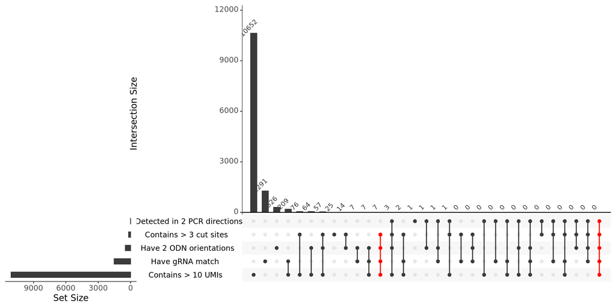

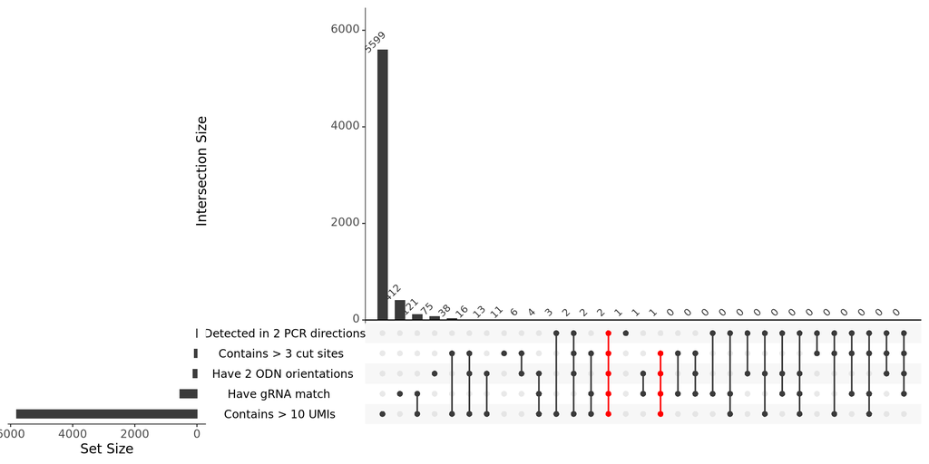

# Graphical representations

## Number of clusters per chromosome

This figure represents the distribution of unique clusters per chromosome, colored by the detection of the gRNA sequence with number of edits (INDELs and substitutions) smaller or equal to **6**.

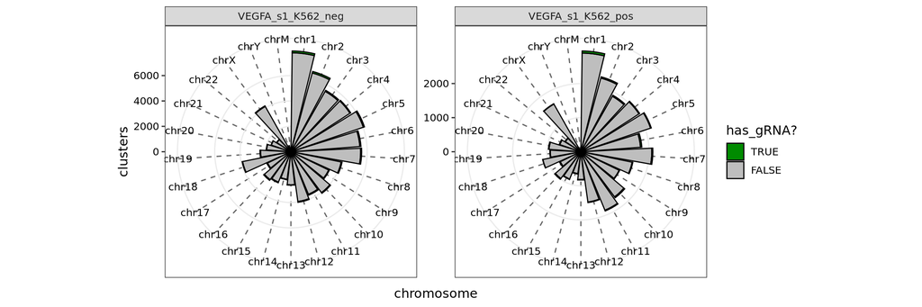

This figure represents the distribution of unique clusters with gRNA match per chromosome, colored by prediction status.

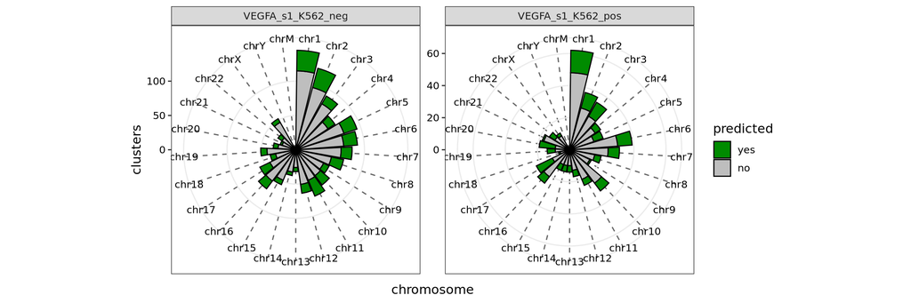

## Number of UMI per chromosome

This figure represents the total number of UMIs (cells) per chromosome, colored by the detection of the gRNA sequence with number of edits (INDELs and substitutions) smaller or equal to **6**.

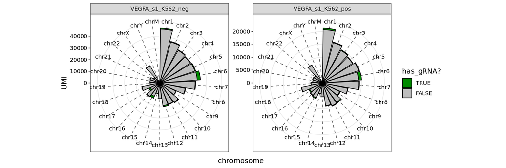

This figure represents the total number of UMIs (cells) per chromosome, for clusters with gRNA match and colored by prediction status.

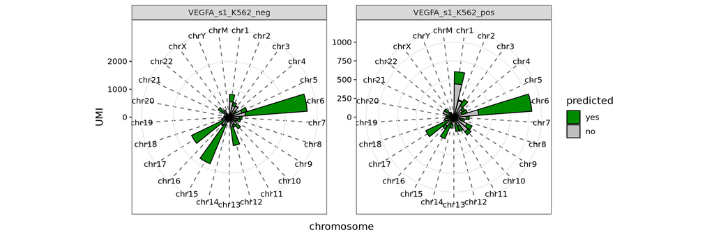

## Rank-abundance curve

The rank-abundance curve is used in ecology to visualize species diversity in a community by plotting species abundance against species rank on logarithmic scales. The resulting curve’s shape provides insights into relative species abundance patterns and community evenness - a steep curve indicates dominance by a few species, while a shallow curve suggests more even distribution of abundances across species.

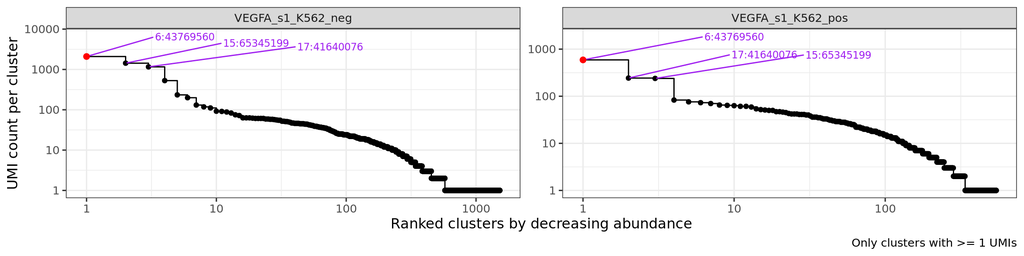

## Distribution of cut sites around best candidates position

See Table 2 for details.

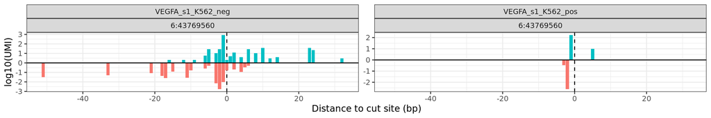

## Distribution of the number of edits in the crRNA

The figure represents the distribution of the number of edits in the crRNA sequence per cluster with gRNA match, colored position prediction status.

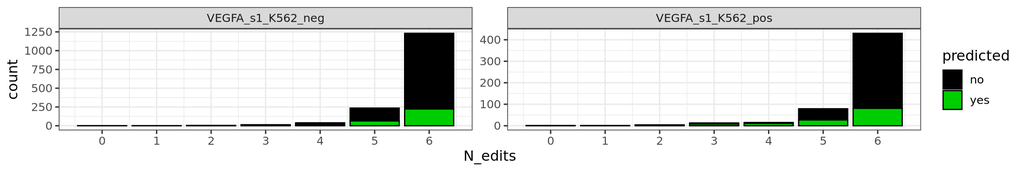

# Configuration settings

```yaml
author: "Guillaume CORRE, PhD"
affiliation: "Therapeutic Gene Editing - GENETHON, INSERM U951, Paris-Saclay University, Evry, France"
contact: "gcorre@genethon.fr"
version: 0.1


## Library informations
sampleInfo_path: "sampleInfo.csv"

read_path:  "/media/Data/common/GuideSeq/RawData/test"
R1: "Undetermined_S0_L001_R1_001.fastq.gz"
R2: "Undetermined_S0_L001_R2_001.fastq.gz"
I1: "Undetermined_S0_L001_I1_001.fastq.gz"
I2: "Undetermined_S0_L001_I2_001.fastq.gz"

rescue_R2: "TRUE"

################################################
## path to references
genome:
  GRCh38:
    fasta: "/media/References/Human/ensembl/GRCh38/Sequences/Homo_sapiens.GRCh38.dna.primary_assembly.fa"
    index: "/media/References/Human/ensembl/GRCh38/Indexes/Bowtie2/Homo_sapiens.GRCh38.dna.primary_assembly" # path to index created during the run if not existing yet
    annotation: "/media/References/Human/ensembl/GRCh38/Annotations/Homo_sapiens.GRCh38.113.chr.gtf.gz"
    oncogene_list: "/media/References/Human/ensembl/GRCh38/Annotations/OncoList_OncoKB_05-20-2025.tsv"
  mouse:
    fasta: ""
    index: ""
    annotation: ""
################################################

################################################
minLength: 25 ## Minimal read length after trimming, before alignment
################################################

## Alignement
################################################
aligner: "bowtie2"   ## Aligner to use (bowtie2 or bwa)
minFragLength: 100         # Minimal fragment length after alignment
maxFragLength: 1500        # Maximal fragment length after alignment
################################################

################################################
# post alignment
minMAPQ: 20                      # Min MAPQ score to keep alignments -> !!! multihits have a MAPQ close to 1. Value greater than 1 will discard Offtargets with exact same sequence.
UMI_hamming_distance: 1         # min distance to cluster UMI using network-based deduplication, use [0] to keep raw UMIs
UMI_deduplication: "Adjacency"  # method to correct UMI (cluster or Adjacency)
UMI_pattern: "NNWNNWNN"
UMI_filter: "FALSE"               # If TRUE, remove UMIs that do no match the expected pattern [FALSE or TRUE]
################################################


################################################
## Off targets calling
tolerate_bulges: "TRUE"           # whether to include gaps in the gRNA alignment (this will change the gap penalty during SW pairwise alignment)
max_edits_crRNA: 6              # filter clusters with less or equal than n edits in the crRNA sequence (edits = substitutions + INDELs)
ISbinWindow: 100                # insertion sites closer than 'ISbinWindow' will be clustered together
minReadsPerUMI: 0               # 0 to keep all UMIs, otherwise min number of reads per UMIs
minUMIPerIS: 0                  # 0 to keep all IS, otherwise min number of UMI per IS
slopSize: 50                    # window size (bp) around IS (both directions) to identify gRNA sequence (ie 50bp = -50bp to +50bp)
min_predicted_distance: 100     # distance between cut site and predicted cut site to consider as predicted
################################################

################################################
# reporting
max_clusters: 100                 # max number of cluster alignments to report
minUMI_alignments_figure: 1       # filter clusters with more than n UMI in the report alignment figure (set to 0 to keep all clusters -> can be slow)
################################################

# Prediction
################################################
SWoffFinder:
  path: "/opt/SWOffinder" ## Path to SWoffinder on your server (downloaded from https://github.com/OrensteinLab/SWOffinder)
  maxE: 6                 # Max edits allowed (integer).
  maxM: 6                 # Max mismatches allowed without bulges (integer).
  maxMB: 6                # Max mismatches allowed with bulges (integer).
  maxB: 3                 # Max bulges allowed (integer).
  window_size: 100
################################################



################################################
# Sequences for the trimming steps

guideseq:
  positive:
    R1_trailing: "GTTTAATTGAGTTGTCATATGT"
    R2_leading: "ACATATGACAACTCAATTAAAC"
    R2_trailing: "AGATCGGAAGAGCGTCGTGT"
  negative:
    R1_trailing: "ATACCGTTATTAACATATGACAACTCAA"
    R2_leading: "TTGAGTTGTCATATGTTAATAACGGTAT"
    R2_trailing: "AGATCGGAAGAGCGTCGTGT"



iguideseq:
  positive:
    R2_leading: "ACATATGACAACTCAATTAAACGCGAGC"
    R2_trailing: "AGATCGGAAGAGCGTCGTGT"
    R1_trailing: "GCTCGCGTTTAATTGAGTTGTCATATGT"
  negative:
    R1_trailing: "TCGCGTATACCGTTATTAACATATGACAACTCAA"
    R2_leading: "TTGAGTTGTCATATGTTAATAACGGTATACGCGA"
    R2_trailing: "AGATCGGAAGAGCGTCGTGT"
################################################
```